# Exploratory Data Analysis (EDA) & Discovery

## Data Acquisition

### Preparation

#### Imports

```python
# data
import pandas as pd
import polars as pl
import numpy as np
import matplotlib.pyplot as plt
import seaborn as sns

# admin
from pathlib import Path
import psutil
import sys
import os

# wgnd
from wgnd.core.theme import setup
from wgnd.core._output import (
    section_header,
    log,
    success,
    warn
)
from wgnd.inspect import (
    inspect,
    inspect_missing,
    inspect_outliers,
    inspect_outlier_detail,
    inspect_correlations,
)
from zh_tram_flow.utils_polars import get_categorical_stats

setup()
```

```
✓  wgnd theme activated (matplotlib · seaborn)
```

#### Settings

```python
%load_ext autoreload
%autoreload 2
```

#### Constants

```python
BASE_DIR        = Path('../')
DATA_RAW_DIR    = BASE_DIR / 'data' / 'raw'
DATA            = DATA_RAW_DIR / 'zh-tram-data-master.parquet'

SEED            = 42

print(DATA)
```

```
../data/raw/zh-tram-data-master.parquet
```

### Data Gathering

```python
# RAM Test Polars Eager vs Lazy

def get_ram():
    process = psutil.Process(os.getpid())
    return process.memory_info().rss / (1024 * 1024)

print(f"RAM: {get_ram():.2f} MB")
available_ram = psutil.virtual_memory().available / (1024**3) # in GB
print(f"Freier RAM: {available_ram:.2f} GB")

#print()
#df_raw = pl.read_parquet(DATA)
#print(f"Nach Eager Read: {get_ram():.2f} MB")

print()
lf_raw = pl.scan_parquet(DATA)
print(f"Nach Lazy Scan: {get_ram():.2f} MB")
print('Lazy Scan, keine Veränderung')

print()
print(f"RAM: {get_ram():.2f} MB")
available_ram = psutil.virtual_memory().available / (1024**3) # in GB
print(f"Freier RAM: {available_ram:.2f} GB")
```

```
RAM: 200.64 MB
Freier RAM: 6.13 GB

Nach Lazy Scan: 200.79 MB
Lazy Scan, keine Veränderung

RAM: 200.79 MB
Freier RAM: 6.13 GB
```

```python
# Der Polars Lazy-Frame
lf = pl.scan_parquet(DATA)

# EDA-Sample: ~5% des Gesamtdatensatzes als Pandas DataFrame für wgnd.inspect
#
# Strategie: gather_every(2) + sample(fraction=0.1)
# → gather_every(2) läuft lazy (vor collect) und halbiert den Datensatz systematisch,
#   d.h. jede zweite Zeile über den gesamten Zeitraum — zeitliche Abdeckung bleibt erhalten.
# → sample(fraction=0.1) zieht danach zufällig 10% aus dieser Hälfte.
# → Ergebnis: ~5% des Gesamtdatensatzes, deterministisch via SEED.
#
# Warum kein stratifiziertes Sampling?
# Für die EDA robust genug: canceled (4.5%) und alle 18 Linien sind bei 5% (~4.5 Mio. Zeilen)
# mit hoher Wahrscheinlichkeit gut vertreten. Stratifizierung nach line_name ist für die
# Modellierungsphase vorgemerkt (BACKLOG #3) — dort kritischer als hier.


df_eda = (
    lf
    .gather_every(2)
    .collect()
    .sample(fraction=0.1, seed=SEED)
    .to_pandas()
)

# Analoge Polars-Variante des Samples (für Polars-spezifische Operationen)
lf_eda = (
    lf
    .gather_every(2)
    .collect()
    .sample(fraction=0.1, seed=SEED)
)

# Bereinigte Delay-Variante: |delay| > 3.600s entfernt — für Verteilungs-Visualisierungen
df_delays_clean = df_eda[df_eda["arrival_delay"].abs() <= 3600].copy()
```

#### Besonderheit für die große Datenmenge

**Best Practice** Das Grundprinzip, bei einer EDA mit großen Datensätzen, heißt "**Lazy first**, **Sample second**, **Full last**" — arbeiten in drei Stufen:

1. Verwendung von **Polars** statt Pandas, um mit der **Lazy-API** deskriptive Statistiken (Mean, Median, Verteilungen) üer den gesamten Datensatz zu berechnen.
2. Verwendung von **Samples** mit Polars für die visuelle Inspektion von Einzelfällen. Vergleich der Sample Mittelwerte mit den Mittelwerte des gesamten Datensatzes.
3. Die Reihenfolge bleibt, Meta-Daten, Statistiken global, Visualisierung via Sample.

##### Sample Strategien

Zufallsauswahl nach Anzahl / 5k

```
df_sample = df.sample(n=5000)
```

Zufallsauswahl nach Anteil / 10%

```
df_sample = df.sample(fraction=0.1)
```

Mit Zurücklegen

```
df_sample = df.sample(fraction=0.1, with_replacement=True)
```

Mit Reproduzierbarkeit

```
df_sample = df.sample(fraction=0.1, seed=42)
```

Systematische Auswahl / jedes 10te

```
df_sample = df.gather_every(10)
```

Kopf- bzw Fußzeilen

```
df_top = df.head(10)
df_bottom = df.tail(10)
```

X zufällige Samples nach Gruppe

```
df_stratified = df.group_by("category").agg(
    pl.all().sample(n=100)
).explode(pl.all())
```

##### Übersicht der Sampling-Methoden in Polars

| Methode | Logik | Anwendungsfall | Performance |
| --- | --- | --- | --- |
| **`.sample(n/fraction)`** | Zufallsauswahl | Repräsentative EDA, Training von ML-Modellen | Mittel |
| **`.gather_every(n)`** | Jedes n-te Element | Zeitreihen, Sensordaten, sehr große Streams | Sehr schnell |
| **`.head(n)` / `.tail(n)`** | Erste / Letzte Zeilen | Schneller Check von Schema und Datentypen | Blitzschnell |
| **`.filter(condition)`** | Logische Bedingung | Fokus auf spezifische Teilpopulationen | Schnell |
| **`.unique()`** | Keine Duplikate | Analyse der Vielfalt von Kategorien | Schnell |
| **`group_by().sample()`** | Pro Gruppe n Zeilen | Stratified Sampling (z.B. bei Betrugserkennung) | Langsamer |

## Analysis

### Basic Statistical Analysis

> *Vollständige EDA-Übersicht mit wgnd.inspect.*

```python
# --- Pandas with wgnd.inspect

result = inspect(df_eda, sections=['memory', 'dimensions', 'dtypes', 'numeric', 'categorical'])
```

```
───  MEMORY  ─────────────────────────────────────────────────
```

|  | column | dtype | memory_kb | memory_pct |
| --- | --- | --- | --- | --- |
| 0 | trip_id | object | 391742.66 | 45.46% |
| 1 | operating_date | datetime64[ms] | 36858.80 | 4.28% |
| 2 | arrival_schedule | datetime64[us] | 36858.80 | 4.28% |
| 3 | departure_schedule | datetime64[us] | 36858.80 | 4.28% |
| 4 | flood_intensity | float64 | 36858.80 | 4.28% |
| 5 | district_nr | float64 | 36858.80 | 4.28% |
| 6 | event_size | float64 | 36858.80 | 4.28% |
| 7 | departure_delay | float32 | 18429.40 | 2.14% |
| 8 | arrival_delay | float32 | 18429.40 | 2.14% |
| 9 | bpuic | int32 | 18429.40 | 2.14% |
| 10 | global_radiation | float32 | 18429.40 | 2.14% |
| 11 | precipitation | float32 | 18429.40 | 2.14% |
| 12 | wind_speed | float32 | 18429.40 | 2.14% |
| 13 | stop_lat | float32 | 18429.40 | 2.14% |
| 14 | rain_duration | float32 | 18429.40 | 2.14% |
| 15 | humidity | float32 | 18429.40 | 2.14% |
| 16 | stop_lon | float32 | 18429.40 | 2.14% |
| 17 | temperature | float32 | 18429.40 | 2.14% |
| 18 | stop_name | category | 9244.36 | 1.07% |
| 19 | stop_sequence | int16 | 9214.70 | 1.07% |
| 20 | event_name | category | 4615.02 | 0.54% |
| 21 | line_name | category | 4608.92 | 0.53% |
| 22 | event_location | category | 4608.76 | 0.53% |
| 23 | district_name | category | 4608.40 | 0.53% |
| 24 | event_type | category | 4608.25 | 0.53% |
| 25 | canceled | bool | 4607.35 | 0.53% |

```
Total: 861734.71 KB  (841.54 MB)

───  DIMENSIONS  ─────────────────────────────────────────────
```

|  | metric | count | pct |
| --- | --- | --- | --- |
| 0 | rows | 4717926 |  |
| 1 | columns | 26 |  |
| 2 | duplicates | 0 | 0.0% |
| 3 | empty rows (all NaN) | 0 | 0.0% |
| 4 | empty cols (all NaN) | 0 | 0.0% |

```
───  DTYPES  ─────────────────────────────────────────────────
```

|  | column | dtype | missing_cnt | missing_pct | unique | unique_pct |
| --- | --- | --- | --- | --- | --- | --- |
| 0 | operating_date | datetime64[ms] | 0 | 0.00% | 1092 | 0.02% |
| 1 | trip_id | object | 0 | 0.00% | 321006 | 6.80% |
| 2 | line_name | category | 0 | 0.00% | 18 | 0.00% |
| 3 | bpuic | int32 | 0 | 0.00% | 634 | 0.01% |
| 4 | arrival_schedule | datetime64[us] | 6906 | 0.15% | 1253941 | 26.58% |
| 5 | arrival_delay | float32 | 11320 | 0.24% | 3637 | 0.08% |
| 6 | departure_schedule | datetime64[us] | 6764 | 0.14% | 1254177 | 26.58% |
| 7 | departure_delay | float32 | 11286 | 0.24% | 3714 | 0.08% |
| 8 | canceled | bool | 0 | 0.00% | 2 | 0.00% |
| 9 | stop_sequence | int16 | 0 | 0.00% | 68 | 0.00% |
| 10 | stop_name | category | 4508 | 0.10% | 223 | 0.00% |
| 11 | stop_lat | float32 | 4508 | 0.10% | 221 | 0.00% |
| 12 | stop_lon | float32 | 4508 | 0.10% | 222 | 0.00% |
| 13 | district_nr | float64 | 325158 | 6.89% | 12 | 0.00% |
| 14 | district_name | category | 325158 | 6.89% | 12 | 0.00% |
| 15 | temperature | float32 | 16584 | 0.35% | 3489 | 0.07% |
| 16 | humidity | float32 | 16584 | 0.35% | 6455 | 0.14% |
| 17 | rain_duration | float32 | 12759 | 0.27% | 1976 | 0.04% |
| 18 | precipitation | float32 | 11815 | 0.25% | 88 | 0.00% |
| 19 | wind_speed | float32 | 13666 | 0.29% | 634 | 0.01% |
| 20 | global_radiation | float32 | 14061 | 0.30% | 11912 | 0.25% |
| 21 | flood_intensity | float64 | 7344 | 0.16% | 6 | 0.00% |
| 22 | event_name | category | 3704729 | 78.52% | 72 | 0.00% |
| 23 | event_type | category | 3704729 | 78.52% | 9 | 0.00% |
| 24 | event_size | float64 | 3704729 | 78.52% | 3 | 0.00% |
| 25 | event_location | category | 3704729 | 78.52% | 12 | 0.00% |

```
───  NUMERIC STATS  ──────────────────────────────────────────
```

|  | column | missing_pct | count | mean | median | std | min | 25% | 75% | max | mean_median_diff | skewness |
| --- | --- | --- | --- | --- | --- | --- | --- | --- | --- | --- | --- | --- |
| 0 | bpuic | 0.00% | 4717926.00 | 9399000.77 | 8591220.00 | 26255697.03 | 8502572.00 | 8591060.00 | 8591335.00 | 859423901.00 | 807780.77 | 32.32 |
| 1 | arrival_delay | 0.24% | 4706606.00 | 56.16 | 42.00 | 113.35 | -29892.00 | 12.00 | 81.00 | 33785.00 | 14.16 | 64.25 |
| 2 | departure_delay | 0.24% | 4706640.00 | 61.76 | 47.00 | 113.26 | -29876.00 | 16.00 | 88.00 | 33785.00 | 14.76 | 59.26 |
| 3 | stop_sequence | 0.00% | 4717926.00 | 12.77 | 11.00 | 8.46 | 1.00 | 6.00 | 19.00 | 70.00 | 1.77 | 0.82 |
| 4 | stop_lat | 0.10% | 4713418.00 | 47.38 | 47.38 | 0.02 | 47.33 | 47.37 | 47.40 | 47.45 | 0.00 | 0.70 |
| 5 | stop_lon | 0.10% | 4713418.00 | 8.54 | 8.54 | 0.02 | 8.44 | 8.53 | 8.55 | 8.64 | 0.00 | -0.53 |
| 6 | district_nr | 6.89% | 4392768.00 | 5.24 | 5.00 | 3.42 | 1.00 | 2.00 | 7.00 | 12.00 | 0.24 | 0.40 |
| 7 | temperature | 0.35% | 4701342.00 | 13.20 | 12.48 | 8.03 | -4.75 | 7.16 | 19.28 | 35.80 | 0.72 | 0.22 |
| 8 | humidity | 0.35% | 4701342.00 | 67.58 | 70.61 | 16.91 | 18.58 | 55.65 | 81.19 | 101.37 | -3.03 | -0.53 |
| 9 | rain_duration | 0.27% | 4705167.00 | 5.92 | 0.00 | 15.81 | 0.00 | 0.00 | 0.00 | 60.00 | 5.92 | 2.67 |
| 10 | precipitation | 0.25% | 4706111.00 | 0.12 | 0.00 | 0.60 | 0.00 | 0.00 | 0.00 | 23.90 | 0.12 | 11.89 |
| 11 | wind_speed | 0.29% | 4704260.00 | 1.93 | 1.74 | 1.02 | 0.25 | 1.19 | 2.44 | 10.08 | 0.19 | 1.31 |
| 12 | global_radiation | 0.30% | 4703865.00 | 185.12 | 65.46 | 243.26 | 0.01 | 0.03 | 296.58 | 1041.18 | 119.66 | 1.34 |
| 13 | flood_intensity | 0.16% | 4710582.00 | 0.07 | 0.00 | 0.48 | 0.00 | 0.00 | 0.00 | 11.00 | 0.07 | 14.87 |
| 14 | event_size | 78.52% | 1013197.00 | 1.46 | 1.00 | 0.57 | 1.00 | 1.00 | 2.00 | 3.00 | 0.46 | 0.77 |

```
───  CATEGORICAL STATS  ──────────────────────────────────────
```

|  | column | missing_pct | missing_cnt | uniques | top_value | top_value_cnt | top_value_freq_pct |
| --- | --- | --- | --- | --- | --- | --- | --- |
| 0 | trip_id | 0.00% | 0 | 321006 | 85:3849:62691-08009-1 | 460 | 0.01% |
| 1 | line_name | 0.00% | 0 | 18 | 11 | 457773 | 9.70% |
| 2 | canceled | 0.00% | 0 | 2 | False | 4490484 | 95.18% |
| 3 | stop_name | 0.10% | 4508 | 223 | Zürich, Paradeplatz | 98184 | 2.08% |
| 4 | district_name | 6.89% | 325158 | 12 | Kreis 1 | 955357 | 20.25% |
| 5 | event_name | 78.52% | 3704729 | 72 | Zürich Design Weeks | 54729 | 1.16% |
| 6 | event_type | 78.52% | 3704729 | 9 | Super League | 433438 | 9.19% |
| 7 | event_location | 78.52% | 3704729 | 12 | Letzigrund | 467976 | 9.92% |

```python
# --- Polars insights

section_header('DIMENSIONS')

schema = lf.collect_schema()

# Anzahl der Spalten (sofort verfügbar)
print(f"Anzahl Spalten: {len(schema)}")

# Zeilenanzahl (erfordert einen schnellen Scan der Metadaten)
print(f"Anzahl Zeilen: {lf.select(pl.len()).collect().item()}")

# Null-Counts pro Spalte — aggregiert
print("Anzahl NaN:")
display(lf.select(pl.all().null_count()).collect())

section_header('DTYPES')

for col_name, dtype in schema.items():
    print(f"{col_name:<20} | Typ: {dtype}")

section_header('NUMERIC STATS')

# Umfassende Statistiken für alle Spalten
display( lf.describe())

section_header('CATEGORICAL STATS ')

# Helper-Funktion aus utils_polars.py
get_categorical_stats(lf_eda)
```

```
───  DIMENSIONS  ─────────────────────────────────────────────
Anzahl Spalten: 26
Anzahl Zeilen: 94358531
Anzahl NaN:
```

shape: (1, 26)

| operating_date u32 | trip_id u32 | line_name u32 | bpuic u32 | arrival_schedule u32 | arrival_delay u32 | departure_schedule u32 | departure_delay u32 | canceled u32 | stop_sequence u32 | stop_name u32 | stop_lat u32 | stop_lon u32 | district_nr u32 | district_name u32 | temperature u32 | humidity u32 | rain_duration u32 | precipitation u32 | wind_speed u32 | global_radiation u32 | flood_intensity u32 | event_name u32 | event_type u32 | event_size u32 | event_location u32 |
| --- | --- | --- | --- | --- | --- | --- | --- | --- | --- | --- | --- | --- | --- | --- | --- | --- | --- | --- | --- | --- | --- | --- | --- | --- | --- |
| 0 | 0 | 0 | 0 | 136437 | 225018 | 136148 | 228075 | 0 | 0 | 91219 | 91219 | 91219 | 6494934 | 6494934 | 329902 | 329902 | 252491 | 236841 | 270230 | 278078 | 144937 | 74118488 | 74118488 | 74118488 | 74118488 |

```
───  DTYPES  ─────────────────────────────────────────────────
operating_date       | Typ: Date
trip_id              | Typ: String
line_name            | Typ: Categorical
bpuic                | Typ: Int32
arrival_schedule     | Typ: Datetime(time_unit='us', time_zone=None)
arrival_delay        | Typ: Float32
departure_schedule   | Typ: Datetime(time_unit='us', time_zone=None)
departure_delay      | Typ: Float32
canceled             | Typ: Boolean
stop_sequence        | Typ: Int16
stop_name            | Typ: Categorical
stop_lat             | Typ: Float32
stop_lon             | Typ: Float32
district_nr          | Typ: Int8
district_name        | Typ: Categorical
temperature          | Typ: Float32
humidity             | Typ: Float32
rain_duration        | Typ: Float32
precipitation        | Typ: Float32
wind_speed           | Typ: Float32
global_radiation     | Typ: Float32
flood_intensity      | Typ: Int16
event_name           | Typ: Categorical
event_type           | Typ: Categorical
event_size           | Typ: Int8
event_location       | Typ: Categorical

───  NUMERIC STATS  ──────────────────────────────────────────
```

shape: (9, 27)

| statistic str | operating_date str | trip_id str | line_name str | bpuic f64 | arrival_schedule str | arrival_delay f64 | departure_schedule str | departure_delay f64 | canceled f64 | stop_sequence f64 | stop_name str | stop_lat f64 | stop_lon f64 | district_nr f64 | district_name str | temperature f64 | humidity f64 | rain_duration f64 | precipitation f64 | wind_speed f64 | global_radiation f64 | flood_intensity f64 | event_name str | event_type str | event_size f64 | event_location str |
| --- | --- | --- | --- | --- | --- | --- | --- | --- | --- | --- | --- | --- | --- | --- | --- | --- | --- | --- | --- | --- | --- | --- | --- | --- | --- | --- |
| "count" | "94358531" | "94358531" | "94358531" | 9.4358531e7 | "94222094" | 9.4133513e7 | "94222383" | 9.4130456e7 | 9.4358531e7 | 9.4358531e7 | "94267312" | 9.4267312e7 | 9.4267312e7 | 8.7863597e7 | "87863597" | 9.4028629e7 | 9.4028629e7 | 9.410604e7 | 9.412169e7 | 9.4088301e7 | 9.4080453e7 | 9.4213594e7 | "20240043" | "20240043" | 2.0240043e7 | "20240043" |
| "null_count" | "0" | "0" | "0" | 0.0 | "136437" | 225018.0 | "136148" | 228075.0 | 0.0 | 0.0 | "91219" | 91219.0 | 91219.0 | 6.494934e6 | "6494934" | 329902.0 | 329902.0 | 252491.0 | 236841.0 | 270230.0 | 278078.0 | 144937.0 | "74118488" | "74118488" | 7.4118488e7 | "74118488" |
| "mean" | "2024-07-01 14:25:47.805181" | null | null | 9.4085e6 | "2024-07-02 12:04:42.307297" | 56.080585 | "2024-07-02 12:03:55.943705" | 61.69416 | 0.04824 | 12.767443 | null | 47.383392 | 8.537123 | 5.244116 | null | 13.205679 | 67.584198 | 5.918949 | 0.117638 | 1.930183 | 185.243271 | 0.068817 | null | null | 1.462097 | null |
| "std" | null | null | null | 2.6408e7 | null | 107.901344 | null | 108.913589 | null | 8.466594 | null | 0.018723 | 0.023162 | 3.41483 | null | 8.027277 | 16.910362 | 15.813949 | 0.594282 | 1.020491 | 243.392288 | 0.47838 | null | null | 0.567754 | null |
| "min" | "2023-01-01" | "85:3849:100000-03007-1" | null | 8.502572e6 | "2023-01-01 04:37:00" | -35964.0 | "2023-01-01 04:37:00" | -35956.0 | 0.0 | 1.0 | null | 47.325005 | 8.444579 | 1.0 | null | -4.75 | 18.58 | 0.0 | 0.0 | 0.25 | 0.01 | 0.0 | null | null | 1.0 | null |
| "25%" | "2023-09-28" | null | null | 8.59106e6 | "2023-09-28 20:45:00" | 12.0 | "2023-09-28 20:44:00" | 16.0 | null | 6.0 | null | 47.369728 | 8.525832 | 2.0 | null | 7.16 | 55.66 | 0.0 | 0.0 | 1.19 | 0.03 | 0.0 | null | null | 1.0 | null |
| "50%" | "2024-06-28" | null | null | 8.59122e6 | "2024-06-28 16:52:00" | 42.0 | "2024-06-28 16:52:00" | 47.0 | null | 11.0 | null | 47.379242 | 8.539834 | 5.0 | null | 12.48 | 70.610001 | 0.0 | 0.0 | 1.74 | 65.639999 | 0.0 | null | null | 1.0 | null |
| "75%" | "2025-04-05" | null | null | 8.591335e6 | "2025-04-06 00:06:00" | 81.0 | "2025-04-06 00:07:00" | 88.0 | null | 19.0 | null | 47.395756 | 8.548299 | 7.0 | null | 19.280001 | 81.199997 | 0.0 | 0.0 | 2.44 | 296.690002 | 0.0 | null | null | 2.0 | null |
| "max" | "2025-12-31" | "ch:1:sjyid:100648:plan:fffdec7… | null | 8.59600701e8 | "2026-01-01 04:46:00" | 35043.0 | "2026-01-01 04:45:00" | 35044.0 | 1.0 | 77.0 | null | 47.452236 | 8.647987 | 12.0 | null | 35.799999 | 101.370003 | 60.0 | 23.9 | 10.08 | 1041.180054 | 11.0 | null | null | 3.0 | null |

```
───  CATEGORICAL STATS   ─────────────────────────────────────
```

shape: (8, 5)

| column str | missing_cnt str | unique str | top_value str | top_value_cnt str |
| --- | --- | --- | --- | --- |
| "trip_id" | "0" | "321006" | "85:3849:62691-08009-1" | "460" |
| "line_name" | "0" | "18" | "11" | "457773" |
| "canceled" | "0" | "2" | "false" | "4490484" |
| "stop_name" | "4508" | "224" | "Zürich, Paradeplatz" | "98184" |
| "district_name" | "325158" | "13" | "Kreis 1" | "955357" |
| "event_name" | "3704729" | "73" | null | "0" |
| "event_type" | "3704729" | "10" | null | "0" |
| "event_location" | "3704729" | "13" | null | "0" |

### Data Completeness

**Quality Check & Duplicates & Missing Values**

```
───  MISSING VALUES  ─────────────────────────────────────────
```

|  | column | missing_cnt | missing_pct |
| --- | --- | --- | --- |
| 0 | event_location | 3704729 | 78.52% |
| 1 | event_size | 3704729 | 78.52% |
| 2 | event_type | 3704729 | 78.52% |
| 3 | event_name | 3704729 | 78.52% |
| 4 | district_nr | 325158 | 6.89% |
| 5 | district_name | 325158 | 6.89% |
| 6 | temperature | 16584 | 0.35% |
| 7 | humidity | 16584 | 0.35% |
| 8 | global_radiation | 14061 | 0.30% |
| 9 | wind_speed | 13666 | 0.29% |
| 10 | rain_duration | 12759 | 0.27% |
| 11 | precipitation | 11815 | 0.25% |
| 12 | departure_delay | 11286 | 0.24% |
| 13 | arrival_delay | 11320 | 0.24% |
| 14 | flood_intensity | 7344 | 0.16% |
| 15 | arrival_schedule | 6906 | 0.15% |
| 16 | departure_schedule | 6764 | 0.14% |
| 17 | stop_lat | 4508 | 0.10% |
| 18 | stop_lon | 4508 | 0.10% |
| 19 | stop_name | 4508 | 0.10% |

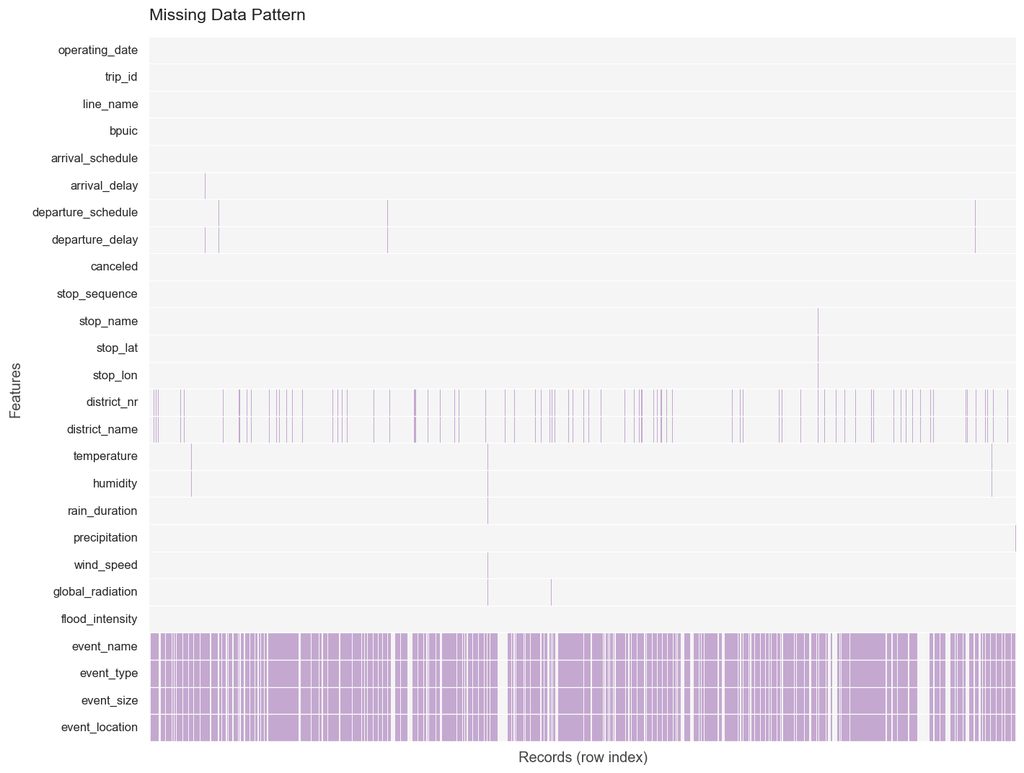

|  | column | missing_cnt | missing_pct |
| --- | --- | --- | --- |
| 0 | event_location | 3704729 | 78.52 |
| 1 | event_size | 3704729 | 78.52 |
| 2 | event_type | 3704729 | 78.52 |
| 3 | event_name | 3704729 | 78.52 |
| 4 | district_nr | 325158 | 6.89 |
| 5 | district_name | 325158 | 6.89 |
| 6 | temperature | 16584 | 0.35 |
| 7 | humidity | 16584 | 0.35 |
| 8 | global_radiation | 14061 | 0.30 |
| 9 | wind_speed | 13666 | 0.29 |
| 10 | rain_duration | 12759 | 0.27 |
| 11 | precipitation | 11815 | 0.25 |
| 12 | departure_delay | 11286 | 0.24 |
| 13 | arrival_delay | 11320 | 0.24 |
| 14 | flood_intensity | 7344 | 0.16 |
| 15 | arrival_schedule | 6906 | 0.15 |
| 16 | departure_schedule | 6764 | 0.14 |
| 17 | stop_lat | 4508 | 0.10 |
| 18 | stop_lon | 4508 | 0.10 |
| 19 | stop_name | 4508 | 0.10 |

```python
# --- Pandas with wgnd.inspect_missing
# --- Und Missing Data Pattern  Heatmap  /// ca. 5 min.

inspect_missing(df_eda)
```

```python
# --- Polars insights for missing values

section_header('Missing Values')


# Null-Counts pro Spalte — aggregiert
print("Anzahl NaN:")
display(lf.select(pl.all().null_count()).collect())

total_items = lf.select(pl.len()).collect().item()

result_missings = (
    lf
    .select(pl.all().null_count())
    .collect()
    .transpose(include_header=True, column_names=["null_count"])
    .with_columns(
        (pl.col("null_count") / total_items * 100).round(2).alias("pct")
    )
)

display(result_missings)
```

```
───  MISSING VALUES  ─────────────────────────────────────────
Anzahl NaN:
```

shape: (1, 26)

| operating_date u32 | trip_id u32 | line_name u32 | bpuic u32 | arrival_schedule u32 | arrival_delay u32 | departure_schedule u32 | departure_delay u32 | canceled u32 | stop_sequence u32 | stop_name u32 | stop_lat u32 | stop_lon u32 | district_nr u32 | district_name u32 | temperature u32 | humidity u32 | rain_duration u32 | precipitation u32 | wind_speed u32 | global_radiation u32 | flood_intensity u32 | event_name u32 | event_type u32 | event_size u32 | event_location u32 |
| --- | --- | --- | --- | --- | --- | --- | --- | --- | --- | --- | --- | --- | --- | --- | --- | --- | --- | --- | --- | --- | --- | --- | --- | --- | --- |
| 0 | 0 | 0 | 0 | 136437 | 225018 | 136148 | 228075 | 0 | 0 | 91219 | 91219 | 91219 | 6494934 | 6494934 | 329902 | 329902 | 252491 | 236841 | 270230 | 278078 | 144937 | 74118488 | 74118488 | 74118488 | 74118488 |

shape: (26, 3)

| column str | null_count u32 | pct f64 |
| --- | --- | --- |
| "operating_date" | 0 | 0.0 |
| "trip_id" | 0 | 0.0 |
| "line_name" | 0 | 0.0 |
| "bpuic" | 0 | 0.0 |
| "arrival_schedule" | 136437 | 0.14 |
| … | … | … |
| "flood_intensity" | 144937 | 0.15 |
| "event_name" | 74118488 | 78.55 |
| "event_type" | 74118488 | 78.55 |
| "event_size" | 74118488 | 78.55 |
| "event_location" | 74118488 | 78.55 |

#### Missings — Schedule vs. Delay Asymmetrie

**Warum interessant?**  
`arrival_schedule` und `arrival_delay` sollten denselben Null-Anteil haben — wenn kein Zeitstempel vorhanden ist, kann auch kein Delay gemessen werden. Die Counts weichen aber ab: Schedule hat weniger Nulls als Delay. Das bedeutet: es gibt Fahrten, bei denen ein Zeitstempel registriert wurde, aber kein Delay-Wert ankam — typischerweise ein Übertragungsfehler im Sensor-/Reporting-System.

**Was ist auffällig?**

[output not shown]

**Empfehlung Cleaning:**

- Zeilen mit `arrival_schedule IS NULL` → rausfiltern (keine Zeitinformation, für Modell nutzlos)
- Zeilen mit `arrival_schedule NOT NULL` aber `arrival_delay IS NULL` → für Ausfallanalyse behalten, für Delay-Modell herausfiltern (kein Zielwert vorhanden)

```python
# --- Finding C1: Missings in arrival/departure schedules and delays

section_header('Missings in schedules and delays')

# Asymmetrie zwischen Schedule- und Delay-Nullwerten prüfen
result_c1 = lf.select([
    pl.col("arrival_schedule").null_count().alias("arrival_schedule_null"),
    pl.col("arrival_delay").null_count().alias("arrival_delay_null"),
    pl.col("departure_schedule").null_count().alias("departure_schedule_null"),
    pl.col("departure_delay").null_count().alias("departure_delay_null"),
]).collect()

display(result_c1)

# Kernfrage: Wie viele Zeilen haben Schedule vorhanden, aber Delay fehlt?
result_c1_detail = lf.select([
    # Schedule null, Delay auch null
    ((pl.col("arrival_schedule").is_null()) & (pl.col("arrival_delay").is_null()))
        .sum().alias("beide_null"),
    # Schedule vorhanden, aber Delay fehlt → Übertragungsfehler
    ((pl.col("arrival_schedule").is_not_null()) & (pl.col("arrival_delay").is_null()))
        .sum().alias("schedule_ok_delay_null"),
    # Schedule fehlt, aber Delay vorhanden → unplausibler Sonderfall
    ((pl.col("arrival_schedule").is_null()) & (pl.col("arrival_delay").is_not_null()))
        .sum().alias("schedule_null_delay_ok"),
]).collect()

display(result_c1_detail)

total = lf.select(pl.len()).collect().item()

nutzlos = result_c1_detail["schedule_ok_delay_null"][0] + result_c1_detail["beide_null"][0]
log(f"\n>> Zeilen ohne verwertbaren Delay-Wert: {nutzlos:,}  ({nutzlos/total*100:.2f}% des Gesamtdatensatzes)")
```

```
───  MISSINGS IN SCHEDULES AND DELAYS  ───────────────────────
```

shape: (1, 4)

| arrival_schedule_null u32 | arrival_delay_null u32 | departure_schedule_null u32 | departure_delay_null u32 |
| --- | --- | --- | --- |
| 136437 | 225018 | 136148 | 228075 |

shape: (1, 3)

| beide_null u32 | schedule_ok_delay_null u32 | schedule_null_delay_ok u32 |
| --- | --- | --- |
| 136437 | 88581 | 0 |

```
>> Zeilen ohne verwertbaren Delay-Wert: 225,018  (0.24% des Gesamtdatensatzes)
```

### Data Integrity

**Invalid Data Detection & Plausibility Check**

**Was ist auffällig?**

[output not shown]

Faustformel: Alles über ±3.600s (±1h) ist unplausibel für regulären Tramverkehr.

**Empfehlung Cleaning:**

- Zeilen mit `|delay| > 3.600s` (1h) → rausfiltern oder als `unreliable` flaggen
- Alternativ: härtere Grenze `|delay| > 1.800s` (30 Min) prüfen — nach Betrachtung der Verteilung entscheiden

```python
# --- Finding I1: Extreme Delay-Werte

section_header('Extreme Delay-Werte')
print()

# Wie viele Zeilen überschreiten plausible Grenzen?
thresholds = [600, 1800, 3600]  # 10 Min, 30 Min, 1 Stunde in Sekunden

for t in thresholds:
    n = lf.filter(
        (pl.col("arrival_delay").abs() > t) | (pl.col("departure_delay").abs() > t)
    ).select(pl.len()).collect().item()
    total = lf.select(pl.len()).collect().item()
    log(f">> delay >> {t:>5}s ({t//60:>2} Min): {n:>8,} Zeilen  ({n/total*100:.3f}%)")

print()

# Die extremsten Fälle anschauen — was steckt dahinter?
extreme = (
    lf
    .filter(pl.col("arrival_delay").abs() > 3600)
    .select(["operating_date", "line_name", "stop_name", "arrival_delay", "departure_delay", "canceled"])
    .sort("arrival_delay")
    .collect()
)

print(f"Zeilen mit |arrival_delay| > 1h: {len(extreme):,}")
print("\nExtremste negative Werte (zu früh):")
display(extreme.head(5))
print("\nExtremste positive Werte (zu spät):")
display(extreme.tail(5))
```

```
───  EXTREME DELAY-WERTE  ────────────────────────────────────

>> delay >>   600s (10 Min):  196,855 Zeilen  (0.209%)
>> delay >>  1800s (30 Min):   22,660 Zeilen  (0.024%)
>> delay >>  3600s (60 Min):    4,899 Zeilen  (0.005%)

Zeilen mit |arrival_delay| > 1h: 4,576

Extremste negative Werte (zu früh):
```

shape: (5, 6)

| operating_date date | line_name cat | stop_name cat | arrival_delay f32 | departure_delay f32 | canceled bool |
| --- | --- | --- | --- | --- | --- |
| 2024-08-08 | "5" | "Zürich, Letzistrasse" | -35964.0 | -35950.0 | false |
| 2024-08-08 | "5" | "Zürich, Voltastrasse" | -35958.0 | -35956.0 | false |
| 2024-08-08 | "5" | "Zürich, Seilbahn Rigiblick" | -35946.0 | -35925.0 | false |
| 2024-08-08 | "5" | "Zürich, Haldenbach" | -35934.0 | -35926.0 | false |
| 2024-08-08 | "5" | "Zürich, Winkelriedstrasse" | -35934.0 | -35934.0 | false |

```
Extremste positive Werte (zu spät):
```

shape: (5, 6)

| operating_date date | line_name cat | stop_name cat | arrival_delay f32 | departure_delay f32 | canceled bool |
| --- | --- | --- | --- | --- | --- |
| 2025-10-25 | "7" | "Zürich, Schwamendingerplatz" | 34805.0 | 34745.0 | true |
| 2025-10-25 | "7" | "Zürich, Roswiesen" | 34865.0 | 34865.0 | true |
| 2025-10-25 | "7" | "Zürich, Glattwiesen" | 34925.0 | 34925.0 | true |
| 2025-10-25 | "7" | "Zürich, Probstei" | 34985.0 | 34985.0 | true |
| 2025-10-25 | "7" | "Zürich, Mattenhof" | 35043.0 | 35044.0 | true |

#### BPUIC-Ausreißer (max 859.600.701)

**Was ist auffällig?**

[output not shown]

Erwarteter Bereich: `8.500.000 – 8.600.000`  
Anomalie-Schwelle: `> 100.000.000`

**Empfehlung Cleaning:**

- Zeilen mit `bpuic > 100.000.000` → rausfiltern
- Prüfen ob diese Zeilen mit bestimmten Linien oder Zeiträumen korrelieren (systematischer Fehler in der Quelle?)

```python
# --- Finding I2: bpuic-Ausreißer

section_header('BPUIC Aussreisser')

bpuic_threshold = 100_000_000

anomale = (
    lf
    .filter(pl.col("bpuic") > bpuic_threshold)
    .select(["operating_date", "line_name", "bpuic", "stop_name"])
    .collect()
)

total = lf.select(pl.len()).collect().item()


# Verteilung der anomalen bpuic-Werte
display(anomale.group_by("bpuic").agg(
    pl.len().alias("n"),
    pl.col("line_name").first().alias("linie"),
    pl.col("operating_date").min().alias("datum_min"),
    pl.col("operating_date").max().alias("datum_max"),
).sort("n", descending=True))

# Normaler Bereich zur Kontrolle
normal_range = lf.select([
    pl.col("bpuic").filter(pl.col("bpuic") <= bpuic_threshold).min().alias("bpuic_min_normal"),
    pl.col("bpuic").filter(pl.col("bpuic") <= bpuic_threshold).max().alias("bpuic_max_normal"),
]).collect()

log(f"\n>> Zeilen mit bpuic > {bpuic_threshold:,}: {len(anomale):,}  ({len(anomale)/total*100:.4f}%)")
log(f"\n>> Normaler bpuic-Bereich: {normal_range['bpuic_min_normal'][0]:,} – {normal_range['bpuic_max_normal'][0]:,}")
```

```
───  BPUIC AUSSREISSER  ──────────────────────────────────────
```

shape: (426, 5)

| bpuic i32 | n u32 | linie cat | datum_min date | datum_max date |
| --- | --- | --- | --- | --- |
| 858734901 | 713 | "14" | 2025-04-30 | 2025-04-30 |
| 858734900 | 710 | "14" | 2025-04-30 | 2025-04-30 |
| 859110501 | 696 | "8" | 2025-04-30 | 2025-04-30 |
| 859110500 | 690 | "8" | 2025-04-30 | 2025-04-30 |
| 859138101 | 585 | "14" | 2025-04-30 | 2025-04-30 |
| … | … | … | … | … |
| 850361000 | 1 | "9" | 2025-04-30 | 2025-04-30 |
| 859123300 | 1 | "3" | 2025-04-30 | 2025-04-30 |
| 859143900 | 1 | "7" | 2025-04-30 | 2025-04-30 |
| 859103400 | 1 | "17" | 2025-04-30 | 2025-04-30 |
| 859119400 | 1 | "9" | 2025-04-30 | 2025-04-30 |

```
>> Zeilen mit bpuic > 100,000,000: 91,137  (0.0966%)

>> Normaler bpuic-Bereich: 8,502,572 – 8,596,007
```

#### Meteo-Lücken (Messausfälle, Rolling Window)

**Warum interessant?**  
Wetterdaten werden stündlich gemessen. Messausfälle entstehen durch Sensor-Neustarts, Wartung oder Übertragungsfehler — sie sind kurz (einzelne Stunden) und zeitlich klumpend. Da der Join auf `floor(arrival_schedule, '1h')` basiert, fallen alle Tramfahrten einer ausgefallenen Stunde gleichzeitig raus. Ein Rolling Mean über ±2 Nachbarstunden füllt diese Lücken zuverlässig.

**Was ist auffällig?**

[output not shown]

**Empfehlung Cleaning:**

- Rolling Mean über `window_size=5` (±2 Stunden) pro Tag: `pl.col("temperature").rolling_mean(5)`
- Wenn keine Nachbarn vorhanden (Beginn/Ende): Tages-Median als Fallback
- `flood_intensity` separat behandeln — Rolling Mean ergibt hier keinen Sinn (Ereignis-Indikator), stattdessen `fill_null(0)`

```python
# --- Finding I3: Meteo-Lücken — Muster und Umfang prüfen

section_header('Meteo-Missings')

meteo_cols = ["temperature", "humidity", "rain_duration", "precipitation", "wind_speed", "global_radiation", "flood_intensity"]

# Null-Counts im Gesamtdatensatz
null_counts = lf.select([pl.col(c).null_count().alias(c) for c in meteo_cols]).collect()
total = lf.select(pl.len()).collect().item()

for col in meteo_cols:
    n = null_counts[col][0]
    print(f"{col:<20} null: {n:>8,}  ({n/total*100:.2f}%)")

print()

# Sind die Ausfälle zeitlich klumpend? → Stunden mit vielen gleichzeitigen Null-Werten
lücken_muster = (
    lf
    .filter(pl.col("temperature").is_null())
    .with_columns(
        pl.col("arrival_schedule").dt.truncate("1h").alias("stunde")
    )
    .group_by("stunde")
    .agg(pl.len().alias("n_fahrten_ohne_meteo"))
    .sort("stunde")
    .collect()
)

print(f"Stunden mit fehlenden Temperaturwerten: {len(lücken_muster):,}")
print("Erste 10 Lücken-Stunden:")
display(lücken_muster.head(10))
```

```
───  METEO-MISSINGS  ─────────────────────────────────────────
temperature          null:  329,902  (0.35%)
humidity             null:  329,902  (0.35%)
rain_duration        null:  252,491  (0.27%)
precipitation        null:  236,841  (0.25%)
wind_speed           null:  270,230  (0.29%)
global_radiation     null:  278,078  (0.29%)
flood_intensity      null:  144,937  (0.15%)

Stunden mit fehlenden Temperaturwerten: 47
Erste 10 Lücken-Stunden:
```

shape: (10, 2)

| stunde datetime[μs] | n_fahrten_ohne_meteo u32 |
| --- | --- |
| null | 136437 |
| 2023-01-13 13:00:00 | 5128 |
| 2023-02-21 11:00:00 | 5374 |
| 2023-02-22 07:00:00 | 5221 |
| 2023-02-22 08:00:00 | 5332 |
| 2023-02-22 14:00:00 | 5189 |
| 2024-02-29 17:00:00 | 5371 |
| 2024-02-29 18:00:00 | 5328 |
| 2024-02-29 19:00:00 | 5211 |
| 2024-02-29 20:00:00 | 4536 |

#### Humidity > 100% (Sensor-Kalibrierungsfehler)

**Warum interessant?**  
Relative Luftfeuchtigkeit ist physikalisch auf 0–100% begrenzt. Werte leicht über 100% (bis ~102%) sind ein bekanntes Kalibrierungsproblem bei Wetterstationen und kein echter Messfehler — aber sie müssen vor dem Modelltraining gekappt werden, da kein ML-Modell mit >100% Luftfeuchtigkeit umgehen kann.

**Was ist auffällig?**

| Kennzahl | Wert |
| --- | --- |
| Max `humidity` (Sample) | 101.37% |
| Erwarteter Wertebereich | 0 – 100% |
| Wahrscheinliche Ursache | Sensor-Kalibrierungsdrift |

Werte unter 0% wären ebenfalls anomal — auch das wird mitgeprüft.

**Empfehlung Cleaning:**

- `humidity` auf `[0, 100]` cappen: `pl.col("humidity").clip(0, 100)`
- Kein Rausfiltern der Zeilen nötig — nur der Wert selbst wird korrigiert

```python
# --- Finding I4: Humidity > 100% und weitere Wertebereichs-Checks

section_header('Humidity Value Check')

# Humidity-Anomalien
result_humidity = lf.select([
    pl.col("humidity").min().alias("min"),
    pl.col("humidity").max().alias("max"),
    (pl.col("humidity") > 100).sum().alias("n_über_100"),
    (pl.col("humidity") < 0).sum().alias("n_unter_0"),
    pl.col("humidity").filter(pl.col("humidity") > 100).mean().alias("mean_über_100"),
]).collect()

display(result_humidity)
total = lf.select(pl.len()).collect().item()

print()

# Plausibilitäts-Check weiterer physikalischer Grenzen
print("Weitere Wertebereichs-Checks:")
checks = lf.select([
    (pl.col("rain_duration") > 60).sum().alias("rain_duration_über_60min"),   # max ist 60 min/h
    (pl.col("rain_duration") < 0).sum().alias("rain_duration_unter_0"),
    (pl.col("wind_speed") < 0).sum().alias("wind_speed_unter_0"),
    (pl.col("temperature") < -30).sum().alias("temperature_unter_minus30"),   # für Zürich unplausibel
    (pl.col("temperature") > 45).sum().alias("temperature_über_45"),          # für Zürich unplausibel
    (pl.col("district_nr") < 1).sum().alias("district_unter_1"),              # gültig: 1-12
    (pl.col("district_nr") > 12).sum().alias("district_über_12"),
]).collect()

display(checks)

log(f">> Anteil > 100%: {result_humidity['n_über_100'][0]:,}  ({result_humidity['n_über_100'][0]/total*100:.3f}%)")
```

```
───  HUMIDITY VALUE CHECK  ───────────────────────────────────
```

shape: (1, 5)

| min f32 | max f32 | n_über_100 u32 | n_unter_0 u32 | mean_über_100 f32 |
| --- | --- | --- | --- | --- |
| 18.58 | 101.370003 | 16202 | 0 | 100.791748 |

```
Weitere Wertebereichs-Checks:
```

shape: (1, 7)

| rain_duration_über_60min u32 | rain_duration_unter_0 u32 | wind_speed_unter_0 u32 | temperature_unter_minus30 u32 | temperature_über_45 u32 | district_unter_1 u32 | district_über_12 u32 |
| --- | --- | --- | --- | --- | --- | --- |
| 0 | 0 | 0 | 0 | 0 | 0 | 0 |

```
>> Anteil > 100%: 16,202  (0.017%)
```

**Warum interessant?**  
Ausgefallene Fahrten (`canceled=True`) sind der extremste Verspätungsfall — keine Verzögerung, sondern kompletter Ausfall. Sie wurden im Wrangling bewusst behalten (worst-case für das Modell). Wichtig zu klären: Haben canceled trips sinnvolle Delay-Werte, oder sind die Delays bei Ausfall null? Das bestimmt wie wir sie im Modell behandeln.

**Was ist auffällig?**

[output not shown]

Frage: Haben canceled trips `arrival_delay = null` (Fahrt kam nicht → keine Messung) oder einen sehr hohen Delay-Wert?

**Empfehlung Cleaning:**

- `canceled=True` Zeilen **behalten** — unverzichtbar für Modell
- Als separate Gruppe oder als Feature `is_canceled` (0/1) kodieren
- Delay-Werte bei canceled=True prüfen: wenn null → für Delay-Vorhersage herausfiltern, für Ausfallmodell behalten

```python
# --- Finding I5: Canceled Trips

section_header('Canceld Trips Analysis')

# Anteil und Verteilung
result_canceled = (
    lf
    .group_by("canceled")
    .agg(pl.len().alias("n"))
    .with_columns((pl.col("n") / pl.col("n").sum() * 100).round(2).alias("pct"))
    .sort("canceled")
    .collect()
)
display(result_canceled)

# Kernfrage: Haben canceled trips Delay-Werte?
result_canceled_delays = (
    lf
    .filter(pl.col("canceled"))
    .select([
        pl.len().alias("total_canceled"),
        pl.col("arrival_delay").null_count().alias("arrival_delay_null"),
        pl.col("departure_delay").null_count().alias("departure_delay_null"),
        pl.col("arrival_delay").mean().alias("mean_arrival_delay"),
        pl.col("arrival_delay").median().alias("median_arrival_delay"),
    ])
    .collect()
)

print("\nCanceled trips — Delay-Analyse:")
display(result_canceled_delays)

# Ausfälle nach Linie — welche Linie hat die meisten?
print("\nAusfälle pro Linie:")
display(
    lf
    .filter(pl.col("canceled"))
    .group_by("line_name")
    .agg(pl.len().alias("n_ausfaelle"))
    .sort("n_ausfaelle", descending=True)
    .collect()
)
```

```
───  CANCELD TRIPS ANALYSIS  ─────────────────────────────────
```

shape: (2, 3)

| canceled bool | n u32 | pct f64 |
| --- | --- | --- |
| false | 89806659 | 95.18 |
| true | 4551872 | 4.82 |

```
Canceled trips — Delay-Analyse:
```

shape: (1, 5)

| total_canceled u32 | arrival_delay_null u32 | departure_delay_null u32 | mean_arrival_delay f32 | median_arrival_delay f32 |
| --- | --- | --- | --- | --- |
| 4551872 | 224993 | 227996 | 51.875221 | 30.0 |

```
Ausfälle pro Linie:
```

shape: (18, 2)

| line_name cat | n_ausfaelle u32 |
| --- | --- |
| "9" | 828676 |
| "10" | 712011 |
| "12" | 548813 |
| "17" | 490566 |
| "7" | 485161 |
| … | … |
| "14" | 93624 |
| "15" | 78836 |
| "51" | 990 |
| "50" | 422 |
| "E" | 28 |

### Data Distribution

**Numerical Features & Categorical Features & Bivariate Analysis**

```python
result = inspect(df_eda, sections=[ 'numeric'])
```

```
───  NUMERIC STATS  ──────────────────────────────────────────
```

|  | column | missing_pct | count | mean | median | std | min | 25% | 75% | max | mean_median_diff | skewness |
| --- | --- | --- | --- | --- | --- | --- | --- | --- | --- | --- | --- | --- |
| 0 | bpuic | 0.00% | 4717926.00 | 9399000.77 | 8591220.00 | 26255697.03 | 8502572.00 | 8591060.00 | 8591335.00 | 859423901.00 | 807780.77 | 32.32 |
| 1 | arrival_delay | 0.24% | 4706606.00 | 56.16 | 42.00 | 113.35 | -29892.00 | 12.00 | 81.00 | 33785.00 | 14.16 | 64.25 |
| 2 | departure_delay | 0.24% | 4706640.00 | 61.76 | 47.00 | 113.26 | -29876.00 | 16.00 | 88.00 | 33785.00 | 14.76 | 59.26 |
| 3 | stop_sequence | 0.00% | 4717926.00 | 12.77 | 11.00 | 8.46 | 1.00 | 6.00 | 19.00 | 70.00 | 1.77 | 0.82 |
| 4 | stop_lat | 0.10% | 4713418.00 | 47.38 | 47.38 | 0.02 | 47.33 | 47.37 | 47.40 | 47.45 | 0.00 | 0.70 |
| 5 | stop_lon | 0.10% | 4713418.00 | 8.54 | 8.54 | 0.02 | 8.44 | 8.53 | 8.55 | 8.64 | 0.00 | -0.53 |
| 6 | district_nr | 6.89% | 4392768.00 | 5.24 | 5.00 | 3.42 | 1.00 | 2.00 | 7.00 | 12.00 | 0.24 | 0.40 |
| 7 | temperature | 0.35% | 4701342.00 | 13.20 | 12.48 | 8.03 | -4.75 | 7.16 | 19.28 | 35.80 | 0.72 | 0.22 |
| 8 | humidity | 0.35% | 4701342.00 | 67.58 | 70.61 | 16.91 | 18.58 | 55.65 | 81.19 | 101.37 | -3.03 | -0.53 |
| 9 | rain_duration | 0.27% | 4705167.00 | 5.92 | 0.00 | 15.81 | 0.00 | 0.00 | 0.00 | 60.00 | 5.92 | 2.67 |
| 10 | precipitation | 0.25% | 4706111.00 | 0.12 | 0.00 | 0.60 | 0.00 | 0.00 | 0.00 | 23.90 | 0.12 | 11.89 |
| 11 | wind_speed | 0.29% | 4704260.00 | 1.93 | 1.74 | 1.02 | 0.25 | 1.19 | 2.44 | 10.08 | 0.19 | 1.31 |
| 12 | global_radiation | 0.30% | 4703865.00 | 185.12 | 65.46 | 243.26 | 0.01 | 0.03 | 296.58 | 1041.18 | 119.66 | 1.34 |
| 13 | flood_intensity | 0.16% | 4710582.00 | 0.07 | 0.00 | 0.48 | 0.00 | 0.00 | 0.00 | 11.00 | 0.07 | 14.87 |
| 14 | event_size | 78.52% | 1013197.00 | 1.46 | 1.00 | 0.57 | 1.00 | 1.00 | 2.00 | 3.00 | 0.46 | 0.77 |

#### Numerische Features — Rohe Verteilung

```
───  NUMERISCHE VERTEILUNGEN — ROHDATEN  ─────────────────────
```

[figure not shown]

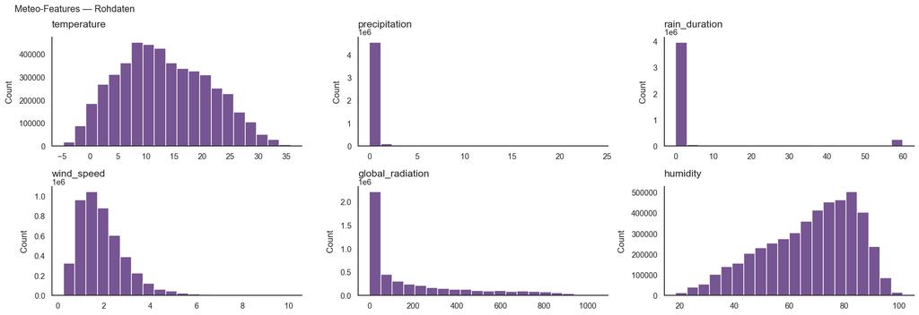

```python
from wgnd.viz import grid_histplot
from wgnd.core.config import cfg

section_header('Numerische Verteilungen — Rohdaten')

# Delays — bereinigt (|delay| ≤ 3.600s) für saubere Skalierung; mit canceled als Hue
fig, _ = grid_histplot(
    df_delays_clean,
    columns=["arrival_delay", "departure_delay"],
    hue="canceled",
    multiple="layer",
    n_cols=2,
    figsize_per_plot=(7, 4),
)
plt.suptitle("Delay-Features — bereinigt (|delay| ≤ 3.600s, orange = canceled)",
             fontsize=13, color=cfg.CHART_TITLE, x=0.02, ha="left", y=1.02)
plt.show()

# Meteo-Features
fig, _ = grid_histplot(
    df_eda,
    columns=["temperature", "precipitation", "rain_duration",
             "wind_speed", "global_radiation", "humidity"],
    n_cols=3,
    figsize_per_plot=(6, 3),
)
plt.suptitle("Meteo-Features — Rohdaten",
             fontsize=13, color=cfg.CHART_TITLE, x=0.02, ha="left", y=1.02)
plt.show()
```

#### Kategorische Features — Verteilung

```
───  KATEGORISCHE VERTEILUNGEN  ──────────────────────────────
```

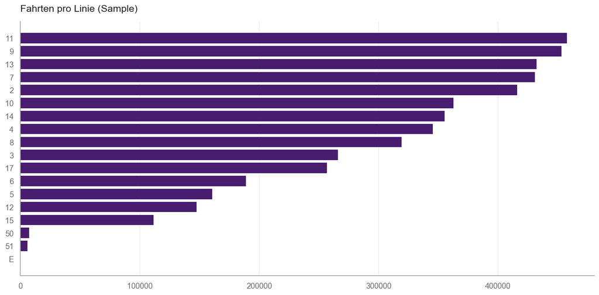

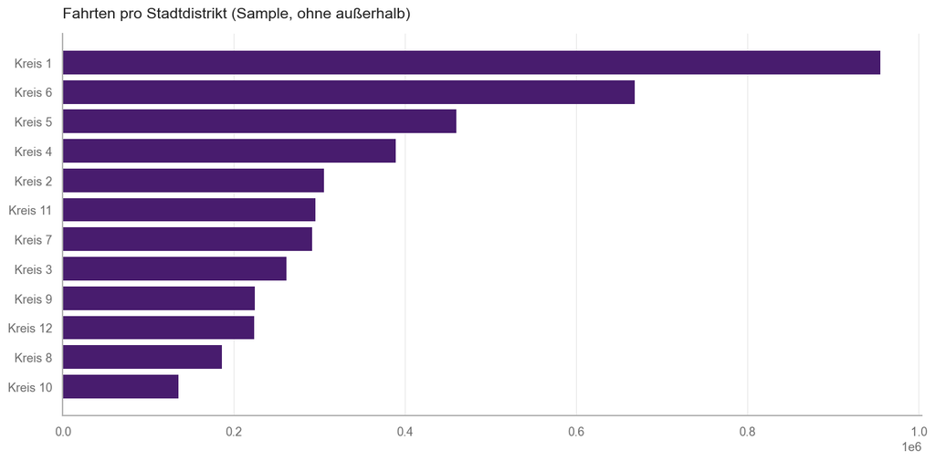

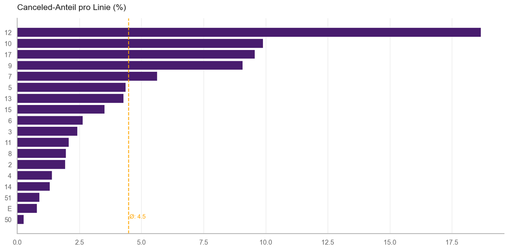

```python
from wgnd.viz import bar

section_header('Kategorische Verteilungen')

# Fahrten pro Linie
line_counts = df_eda["line_name"].value_counts().sort_values()
fig, ax = bar(line_counts, orient="h", title="Fahrten pro Linie (Sample)")
plt.show()

# Fahrten pro Stadtdistrikt (ohne null)
district_counts = df_eda["district_name"].dropna().value_counts().sort_values()
fig, ax = bar(district_counts, orient="h", title="Fahrten pro Stadtdistrikt (Sample, ohne außerhalb)")
plt.show()

# Canceled-Anteil pro Linie — stacked bar
line_cancel = (
    df_eda.groupby("line_name", observed=True)["canceled"]
    .value_counts(normalize=True)
    .mul(100)
    .rename("pct")
    .reset_index()
)
canceled_pct = (
    line_cancel[line_cancel["canceled"] == True]
    .set_index("line_name")["pct"]
    .sort_values()
)
fig, ax = bar(
    canceled_pct, orient="h",
    title="Canceled-Anteil pro Linie (%)",
    ref_val=canceled_pct.mean(), ref_label="Ø"
)
plt.show()
```

#### Beurteilung der Verteilungen

[output not shown]

### Data Relationships

**Correlations**

```python
import matplotlib.pyplot as plt
from wgnd.core.config import cfg

# Session-Patch: installed wgnd version erwartet noch PALETTE_DIVERGENT
# Permanent-Fix benötigt uv reinstall — hier temporäre Lösung für diese Session
_prg = plt.get_cmap(cfg.PALETTE_DIV)
cfg.PALETTE_DIVERGENT = [_prg(i / 6) for i in range(7)]
print("✅ Session-Patch aktiv")
```

```
✅ Session-Patch aktiv
```

```
───  CORRELATIONS  ───────────────────────────────────────────
```

|  | bpuic | arrival_delay | departure_delay | stop_sequence | stop_lat | stop_lon | district_nr | temperature | humidity | rain_duration | precipitation | wind_speed | global_radiation | flood_intensity | event_size |
| --- | --- | --- | --- | --- | --- | --- | --- | --- | --- | --- | --- | --- | --- | --- | --- |
| bpuic | 1.00 | -0.00 | -0.00 | -0.00 | 0.18 | -0.10 | 0.04 | 0.03 | -0.04 | -0.01 | -0.01 | -0.01 | 0.03 | -0.00 | 0.00 |
| arrival_delay | -0.00 | 1.00 | 0.96 | 0.10 | 0.01 | 0.01 | 0.03 | 0.01 | -0.00 | 0.03 | 0.03 | 0.01 | -0.00 | 0.00 | 0.02 |
| departure_delay | -0.00 | 0.96 | 1.00 | 0.10 | 0.01 | 0.01 | 0.02 | 0.00 | 0.00 | 0.03 | 0.03 | 0.01 | -0.01 | 0.00 | 0.02 |
| stop_sequence | -0.00 | 0.10 | 0.10 | 1.00 | 0.02 | 0.02 | 0.05 | -0.00 | -0.01 | 0.00 | 0.00 | 0.01 | 0.01 | 0.00 | -0.02 |
| stop_lat | 0.18 | 0.01 | 0.01 | 0.02 | 1.00 | 0.13 | 0.68 | -0.00 | -0.00 | 0.00 | 0.00 | 0.00 | -0.00 | -0.00 | 0.00 |
| stop_lon | -0.10 | 0.01 | 0.01 | 0.02 | 0.13 | 1.00 | 0.16 | -0.00 | -0.00 | 0.00 | 0.00 | 0.00 | 0.00 | -0.00 | -0.00 |
| district_nr | 0.04 | 0.03 | 0.02 | 0.05 | 0.68 | 0.16 | 1.00 | -0.00 | 0.00 | 0.00 | 0.00 | -0.00 | -0.00 | -0.00 | 0.01 |
| temperature | 0.03 | 0.01 | 0.00 | -0.00 | -0.00 | -0.00 | -0.00 | 1.00 | -0.59 | -0.11 | -0.02 | 0.01 | 0.51 | 0.05 | 0.14 |
| humidity | -0.04 | -0.00 | 0.00 | -0.01 | -0.00 | -0.00 | 0.00 | -0.59 | 1.00 | 0.36 | 0.20 | -0.19 | -0.55 | 0.05 | -0.03 |
| rain_duration | -0.01 | 0.03 | 0.03 | 0.00 | 0.00 | 0.00 | 0.00 | -0.11 | 0.36 | 1.00 | 0.56 | 0.11 | -0.21 | 0.09 | -0.07 |
| precipitation | -0.01 | 0.03 | 0.03 | 0.00 | 0.00 | 0.00 | 0.00 | -0.02 | 0.20 | 0.56 | 1.00 | 0.08 | -0.11 | 0.15 | -0.04 |
| wind_speed | -0.01 | 0.01 | 0.01 | 0.01 | 0.00 | 0.00 | -0.00 | 0.01 | -0.19 | 0.11 | 0.08 | 1.00 | 0.12 | 0.01 | -0.09 |
| global_radiation | 0.03 | -0.00 | -0.01 | 0.01 | -0.00 | 0.00 | -0.00 | 0.51 | -0.55 | -0.21 | -0.11 | 0.12 | 1.00 | -0.01 | 0.04 |
| flood_intensity | -0.00 | 0.00 | 0.00 | 0.00 | -0.00 | -0.00 | -0.00 | 0.05 | 0.05 | 0.09 | 0.15 | 0.01 | -0.01 | 1.00 | -0.01 |
| event_size | 0.00 | 0.02 | 0.02 | -0.02 | 0.00 | -0.00 | 0.01 | 0.14 | -0.03 | -0.07 | -0.04 | -0.09 | 0.04 | -0.01 | 1.00 |

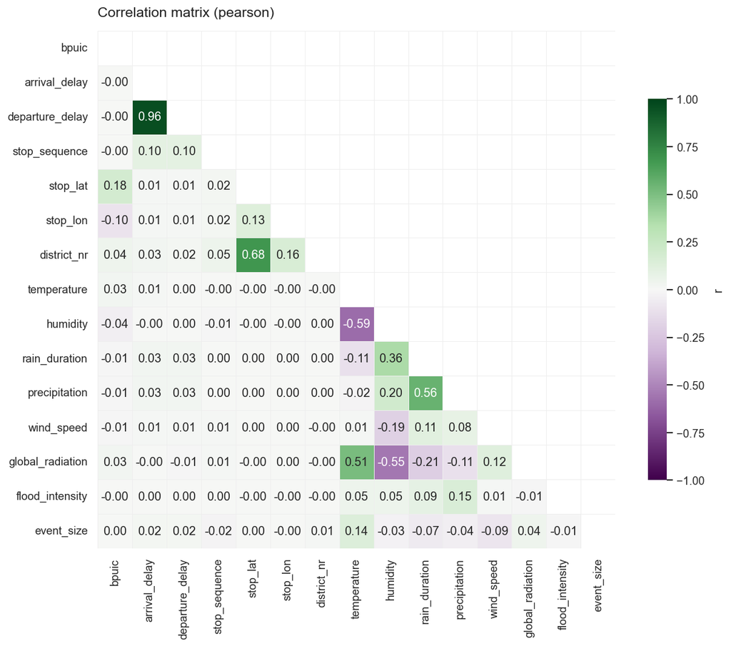

```
1 highly correlated pair(s) (|r| ≥ 0.8): arrival_delay↔departure_delay
```

```
⚠  1 highly correlated pair(s) (|r| ≥ 0.8): arrival_delay↔departure_delay
```

[output not shown]

[output cut: 29 more lines]

[output not shown]

```python
inspect_correlations(df_eda)
# inspect_correlations(df_eda, target='your_target_col', show_pairplot=True)
```

#### Korrelations-Findings

[output not shown]

> **Modellierungs-Fazit:** Schwache lineare Korrelationen zwischen Wetter und Delay sind kein Zeichen für Irrelevanz — sie zeigen Nicht-Linearität. XGBoost kann Schwellenwert-Effekte (Starkregen, Extremtemperatur) erkennen, wo Pearson-r versagt. Feature-Engineering-Ideen (Extremwert-Flags, Interaktionen Regen × Distrikt) → Phase 3.

### Outlier Detection

```python
inspect_outliers(df_eda)
# inspect_outlier_detail(df_eda, 'your_col')
```

```
───  OUTLIERS  ───────────────────────────────────────────────
```

|  | column | mean | median | mean_med_diff | lower_1.5x | upper_1.5x | outliers_1.5x | outliers_1.5x_% | lower_3x | upper_3x | outliers_3x | outliers_3x_% |
| --- | --- | --- | --- | --- | --- | --- | --- | --- | --- | --- | --- | --- |
| 0 | bpuic | 9399000.77 | 8591220.00 | 807780.77 | 8590647.50 | 8591747.50 | 1004444 | 21.29% | 8590235.00 | 8592160.00 | 865219 | 18.34% |
| 1 | rain_duration | 5.92 | 0.00 | 5.92 | 0.00 | 0.00 | 878234 | 18.67% | 0.00 | 0.00 | 878234 | 18.67% |
| 2 | precipitation | 0.12 | 0.00 | 0.12 | 0.00 | 0.00 | 536327 | 11.40% | 0.00 | 0.00 | 536327 | 11.40% |
| 3 | stop_lon | 8.54 | 8.54 | -0.00 | 8.49 | 8.58 | 326261 | 6.92% | 8.46 | 8.62 | 29764 | 0.63% |
| 4 | arrival_delay | 56.16 | 42.00 | 14.16 | -91.50 | 184.50 | 234247 | 4.98% | -195.00 | 288.00 | 71547 | 1.52% |
| 5 | global_radiation | 185.12 | 65.46 | 119.66 | -444.79 | 741.40 | 228357 | 4.85% | -889.62 | 1186.23 | 0 | 0.00% |
| 6 | departure_delay | 61.76 | 47.00 | 14.76 | -92.00 | 196.00 | 220501 | 4.68% | -200.00 | 304.00 | 66920 | 1.42% |
| 7 | flood_intensity | 0.07 | 0.00 | 0.07 | 0.00 | 0.00 | 208178 | 4.42% | 0.00 | 0.00 | 208178 | 4.42% |
| 8 | wind_speed | 1.93 | 1.74 | 0.19 | -0.68 | 4.32 | 139595 | 2.97% | -2.56 | 6.19 | 15344 | 0.33% |
| 9 | stop_lat | 47.38 | 47.38 | 0.00 | 47.33 | 47.43 | 89644 | 1.90% | 47.29 | 47.47 | 0 | 0.00% |
| 10 | stop_sequence | 12.77 | 11.00 | 1.77 | -13.50 | 38.50 | 31850 | 0.68% | -33.00 | 58.00 | 2469 | 0.05% |
| 11 | district_nr | 5.24 | 5.00 | 0.24 | -5.50 | 14.50 | 0 | 0.00% | -13.00 | 22.00 | 0 | 0.00% |
| 12 | humidity | 67.58 | 70.61 | -3.03 | 17.34 | 119.50 | 0 | 0.00% | -20.97 | 157.81 | 0 | 0.00% |
| 13 | temperature | 13.20 | 12.48 | 0.72 | -11.02 | 37.46 | 0 | 0.00% | -29.20 | 55.64 | 0 | 0.00% |
| 14 | event_size | 1.46 | 1.00 | 0.46 | -0.50 | 3.50 | 0 | 0.00% | -2.00 | 5.00 | 0 | 0.00% |

```
→ inspect_outlier_detail(df, col) for boxplot+histogram per feature.
```

|  | column | mean | median | mean_med_diff | lower_1.5x | upper_1.5x | outliers_1.5x | outliers_1.5x_% | lower_3x | upper_3x | outliers_3x | outliers_3x_% |
| --- | --- | --- | --- | --- | --- | --- | --- | --- | --- | --- | --- | --- |
| 0 | bpuic | 9399000.77 | 8591220.00 | 807780.77 | 8590647.50 | 8591747.50 | 1004444 | 21.29 | 8590235.00 | 8592160.00 | 865219 | 18.34 |
| 1 | rain_duration | 5.92 | 0.00 | 5.92 | 0.00 | 0.00 | 878234 | 18.67 | 0.00 | 0.00 | 878234 | 18.67 |
| 2 | precipitation | 0.12 | 0.00 | 0.12 | 0.00 | 0.00 | 536327 | 11.40 | 0.00 | 0.00 | 536327 | 11.40 |
| 3 | stop_lon | 8.54 | 8.54 | -0.00 | 8.49 | 8.58 | 326261 | 6.92 | 8.46 | 8.62 | 29764 | 0.63 |
| 4 | arrival_delay | 56.16 | 42.00 | 14.16 | -91.50 | 184.50 | 234247 | 4.98 | -195.00 | 288.00 | 71547 | 1.52 |
| 5 | global_radiation | 185.12 | 65.46 | 119.66 | -444.79 | 741.40 | 228357 | 4.85 | -889.62 | 1186.23 | 0 | 0.00 |
| 6 | departure_delay | 61.76 | 47.00 | 14.76 | -92.00 | 196.00 | 220501 | 4.68 | -200.00 | 304.00 | 66920 | 1.42 |
| 7 | flood_intensity | 0.07 | 0.00 | 0.07 | 0.00 | 0.00 | 208178 | 4.42 | 0.00 | 0.00 | 208178 | 4.42 |
| 8 | wind_speed | 1.93 | 1.74 | 0.19 | -0.68 | 4.32 | 139595 | 2.97 | -2.56 | 6.19 | 15344 | 0.33 |
| 9 | stop_lat | 47.38 | 47.38 | 0.00 | 47.33 | 47.43 | 89644 | 1.90 | 47.29 | 47.47 | 0 | 0.00 |
| 10 | stop_sequence | 12.77 | 11.00 | 1.77 | -13.50 | 38.50 | 31850 | 0.68 | -33.00 | 58.00 | 2469 | 0.05 |
| 11 | district_nr | 5.24 | 5.00 | 0.24 | -5.50 | 14.50 | 0 | 0.00 | -13.00 | 22.00 | 0 | 0.00 |
| 12 | humidity | 67.58 | 70.61 | -3.03 | 17.34 | 119.50 | 0 | 0.00 | -20.97 | 157.81 | 0 | 0.00 |
| 13 | temperature | 13.20 | 12.48 | 0.72 | -11.02 | 37.46 | 0 | 0.00 | -29.20 | 55.64 | 0 | 0.00 |
| 14 | event_size | 1.46 | 1.00 | 0.46 | -0.50 | 3.50 | 0 | 0.00 | -2.00 | 5.00 | 0 | 0.00 |

#### Delay-Features — Outlier Detail (IQR 1.5× und 3×)

```
───  DELAY OUTLIER — VOR / NACH BEREINIGUNG  ─────────────────
Roh: 4,717,926 Zeilen  →  Bereinigt: 4,706,348 Zeilen  (11,578 entfernt, 0.245%)

── arrival_delay  ROH ──
```

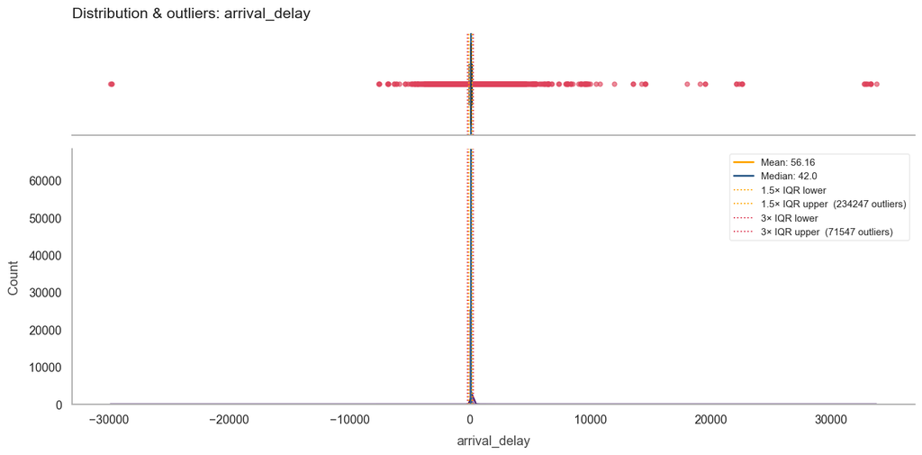

```
── arrival_delay  BEREINIGT (|delay| ≤ 3.600s) ──
```

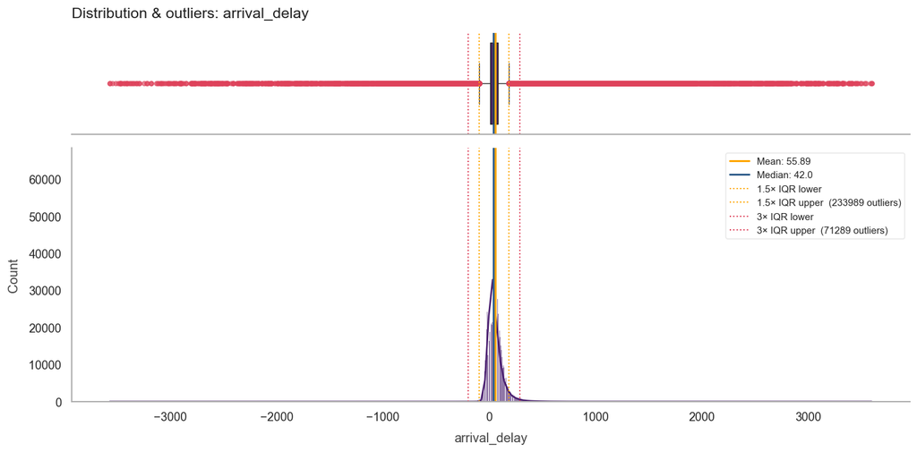

```
── departure_delay  ROH ──
```

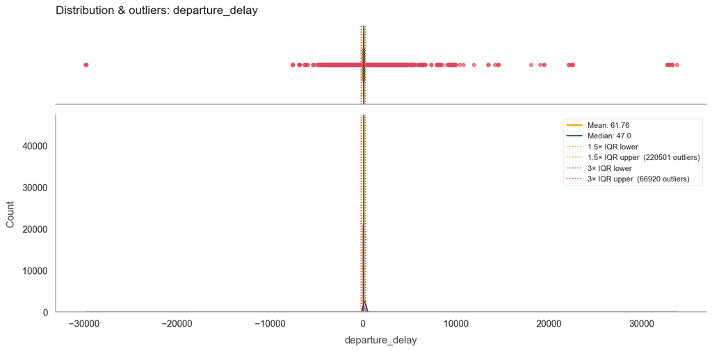

```
── departure_delay  BEREINIGT ──
```

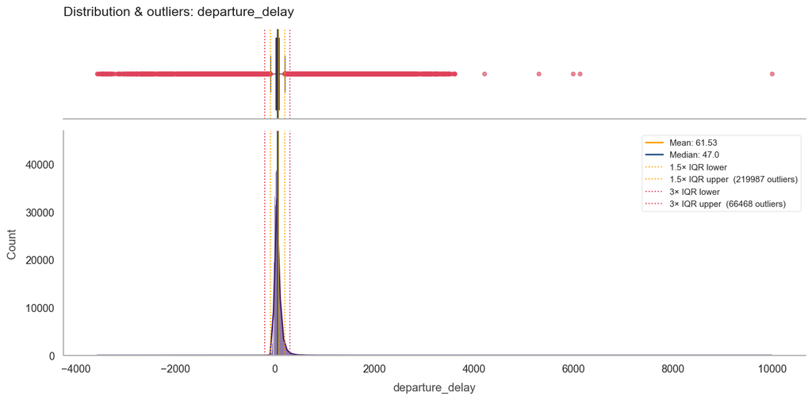

```python
section_header('Delay Outlier — Vor / Nach Bereinigung')
log(f"Roh: {len(df_eda):,} Zeilen  →  Bereinigt: {len(df_delays_clean):,} Zeilen  "
    f"({len(df_eda) - len(df_delays_clean):,} entfernt, "
    f"{(len(df_eda) - len(df_delays_clean)) / len(df_eda) * 100:.3f}%)")

print("\n── arrival_delay  ROH ──")
inspect_outlier_detail(df_eda, "arrival_delay")

print("\n── arrival_delay  BEREINIGT (|delay| ≤ 3.600s) ──")
inspect_outlier_detail(df_delays_clean, "arrival_delay")

print("\n── departure_delay  ROH ──")
inspect_outlier_detail(df_eda, "departure_delay")

print("\n── departure_delay  BEREINIGT ──")
inspect_outlier_detail(df_delays_clean, "departure_delay")
```

#### Meteo-Features — Outlier Detail (precipitation, wind_speed, temperature)

```
───  METEO OUTLIER DETAIL  ───────────────────────────────────
```

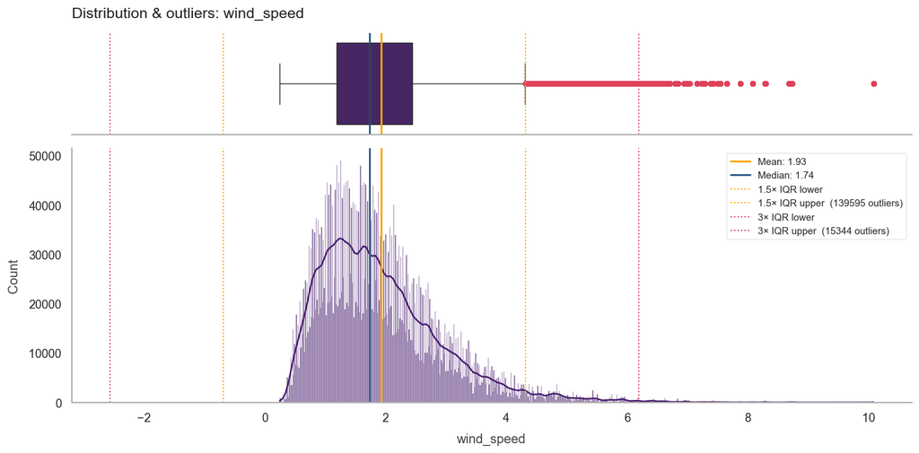

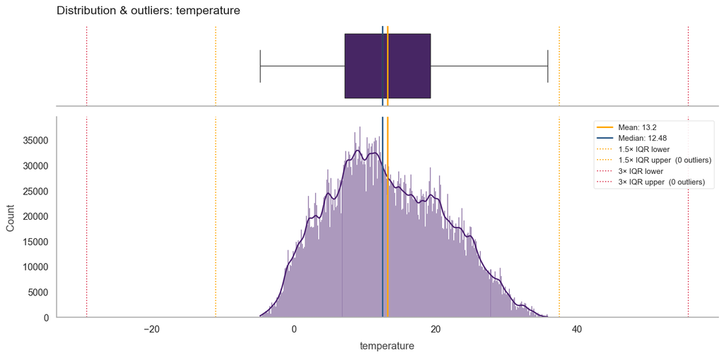

```
───  PRECIPITATION — NORMAL VS. LOG-SKALA  ───────────────────
```

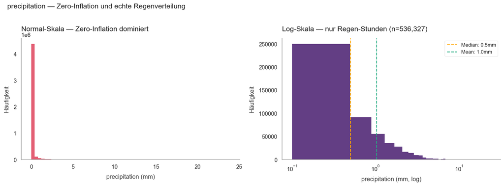

```
✓  Regen-Stunden: 536,327 von 4,706,111 (11.4%) — 88.6% sind 0
```

```python
from wgnd.core.theme import mpl_style
from wgnd.core.config import cfg

section_header('Meteo Outlier Detail')

# wind_speed und temperature: inspect_outlier_detail reicht
inspect_outlier_detail(df_eda, "wind_speed")
inspect_outlier_detail(df_eda, "temperature")

# precipitation: Zero-Inflation + Log-Skala Gegenüberstellung
section_header('Precipitation — Normal vs. Log-Skala')

style = mpl_style()
data      = df_eda["precipitation"].dropna()
data_nz   = data[data > 0]

fig, axes = plt.subplots(1, 2, figsize=(14, 5))

# Links: Normal — Zero-Inflation sichtbar
axes[0].hist(data, bins=60, color=cfg.COLOR_NEGATIVE, alpha=0.85, edgecolor="none")
axes[0].set_title("Normal-Skala — Zero-Inflation dominiert", **style["title"])
axes[0].set_xlabel("precipitation (mm)", **style["label"])
axes[0].set_ylabel("Häufigkeit", **style["label"])
axes[0].spines[["top", "right"]].set_visible(False)
axes[0].spines[["left", "bottom"]].set_color(cfg.CHART_AXIS)

# Rechts: Log-Skala, nur Regen-Stunden
axes[1].hist(data_nz, bins=60, color=cfg.ACTIVE_PALETTE[0], alpha=0.85, edgecolor="none")
axes[1].set_xscale("log")
axes[1].set_title(f"Log-Skala — nur Regen-Stunden (n={len(data_nz):,})", **style["title"])
axes[1].set_xlabel("precipitation (mm, log)", **style["label"])
axes[1].set_ylabel("Häufigkeit", **style["label"])
axes[1].axvline(data_nz.median(), color=cfg.COLOR_SIGNAL, linewidth=1.5,
                linestyle="--", label=f"Median: {data_nz.median():.1f}mm")
axes[1].axvline(data_nz.mean(), color=cfg.COLOR_POSITIVE, linewidth=1.5,
                linestyle="--", label=f"Mean: {data_nz.mean():.1f}mm")
axes[1].legend(fontsize=10)
axes[1].spines[["top", "right"]].set_visible(False)
axes[1].spines[["left", "bottom"]].set_color(cfg.CHART_AXIS)

plt.suptitle("precipitation — Zero-Inflation und echte Regenverteilung",
             fontsize=14, color=cfg.CHART_TITLE, ha="left", x=0.02, y=1.02)
plt.tight_layout()
plt.show()

success(f"Regen-Stunden: {len(data_nz):,} von {len(data):,} "
        f"({len(data_nz)/len(data)*100:.1f}%) — "
        f"{100 - len(data_nz)/len(data)*100:.1f}% sind 0")
```

#### Outlier-Findings

[output not shown]

### Features Inspection

**Engineering Inspection**

```python
# Feature Engineering — erste Ideen aus der EDA (Umsetzung in 02_preparation.ipynb)
#
# Zeitfeatures
# stunde         : arrival_schedule.dt.hour          → Tagesrhythmus
# wochentag      : arrival_schedule.dt.weekday       → Mo=0, So=6
# monat          : arrival_schedule.dt.month         → Saisonalität (R3: Events saisonal)
# ist_wochenende : wochentag >= 5
# ist_hvz        : stunde in [7,8,9,17,18,19]        → Hauptverkehrszeit
#
# Binäre Extremwert-Flags (aus R2/R4/O3)
# hat_regen      : precipitation > 0
# hat_starkregen : precipitation > 5.0               → Schwellenwert aus Viz (Log-Skala)
# hat_flut       : flood_intensity > 0
# hat_wind       : wind_speed > 40                   → nach Outlier-Analyse bestimmen
#
# Kategoriale Encodings
# line_name      : Label-Encoding oder Target-Encoding
# district_name  : Label-Encoding (inkl. Kategorie "ausserhalb" für Nulls)
# event_size     : Ordinal — kein Event=0, klein=1, mittel=2, groß=3
# is_canceled    : bereits vorhanden als bool → zu int konvertieren
#
# Interaktionen (für Phase 4, nach Feature Importance)
# hat_regen × district_nr → Welche Stadtkreise leiden bei Regen stärker?
# ist_hvz × line_name     → Welche Linien sind in der HVZ am instabilsten?

print("Feature Engineering — erste Ideen notiert. Umsetzung in 02_preparation.ipynb.")
```

```
Feature Engineering — erste Ideen notiert. Umsetzung in 02_preparation.ipynb.
```

#### Feature-Ideen — Übersicht

[output not shown]

## Key Findings & Next Steps

### Konsolidierte Findings — nach Topic

[output not shown]

> **Vor Split?** — ✓ = strukturelles Cleaning (Domainregeln, keine statistischen Parameter → kein Leakage-Risiko)  
> **Nach Split** = statistisch abgeleitete Werte (Rolling Mean, IQR-Grenzen, Encoding) → nur auf Trainingsdaten fitten, auf Testdaten anwenden

### Offene Fragen — alle in der EDA beantwortet

[output not shown]

### Prognose der Datensatz-Reduktion nach dem Cleaning

[output not shown]